# SOEP-RKI: Big Five Personality Traits and COVID-19 Antibodies

Michael D. Krämer

6/10/2021

#### Load packages

```r
library("tidyverse")
library("DescTools")
library("survey")
```

#### Load data

```r
source("covid-pers-merge.R") # This executes data import & cleaning.
```

#### Inspect data

This dataset still contains around 3.6% missings for the Big Five. These respondents have never filled out the Big Five (validly). I’ve now used all available data from 2005-2019 to fill in later missings in the Big Five. The variable *lastwave* shows the most recent wave where a respondent answered the Big Five (at least one item - individual missing Big Five traits are also filled in from earlier waves, though).

```r
table(covid_pers$core) # 0 = SOEP-IS, 1 = SOEP-Core
```

```
##
##     0     1
##  2166 12413
```

```r
table(covid_pers$core, covid_pers$infekt_pos)
```

```
##
##         0     1
##   0  2132    34
##   1 12172   241
```

```r
table(covid_pers$core, covid_pers$AK_pos)
```

```
##
##         0     1
##   0  2097    21
##   1 11968   162
```

```r
summary(covid_pers)
```

```
##       pid                hid               hhgr            sex
##  Min.   :     901   Min.   :     94   Min.   :1.000   Min.   :1.000
##  1st Qu.: 5182202   1st Qu.: 500626   1st Qu.:2.000   1st Qu.:1.000
##  Median :21376301   Median :2120162   Median :2.000   Median :2.000
##  Mean   :18765760   Mean   :1834001   Mean   :2.623   Mean   :1.536
##  3rd Qu.:27389001   3rd Qu.:2735566   3rd Qu.:4.000   3rd Qu.:2.000
##  Max.   :41726501   Max.   :4172650   Max.   :9.000   Max.   :2.000
##                                                       NA's   :79
##  schulabschluss       bula        phrf_20_final   phrf_20_final_dbs
##  Min.   :1.000   Min.   : 1.000   Min.   :    1   Min.   :    1
##  1st Qu.:2.000   1st Qu.: 5.000   1st Qu.: 1015   1st Qu.: 1031
##  Median :2.000   Median : 8.000   Median : 2517   Median : 2558
##  Mean   :2.675   Mean   : 7.658   Mean   : 4575   Mean   : 4681
##  3rd Qu.:4.000   3rd Qu.: 9.000   3rd Qu.: 5627   3rd Qu.: 5734
##  Max.   :6.000   Max.   :16.000   Max.   :52368   Max.   :58746
##  NA's   :3701    NA's   :5                        NA's   :341
##       age           ageGroup        numKids         pgcasmin
##  Min.   :18.00   Min.   :1.000   Min.   :0.000   Min.   :0.00
##  1st Qu.:40.00   1st Qu.:2.000   1st Qu.:0.000   1st Qu.:5.00
##  Median :53.00   Median :3.000   Median :0.000   Median :6.00
##  Mean   :51.99   Mean   :2.669   Mean   :0.697   Mean   :5.99
##  3rd Qu.:65.00   3rd Qu.:4.000   3rd Qu.:1.000   3rd Qu.:8.00
##  Max.   :99.00   Max.   :4.000   Max.   :7.000   Max.   :9.00
##                  NA's   :143     NA's   :5       NA's   :1430
##      hghinc           AK_pos        infekt_pos           open
##  Min.   :    35   Min.   :0.000   Min.   :0.00000   Min.   :1.000
##  1st Qu.:  2400   1st Qu.:0.000   1st Qu.:0.00000   1st Qu.:4.250
##  Median :  3500   Median :0.000   Median :0.00000   Median :5.000
##  Mean   :  4188   Mean   :0.013   Mean   :0.01905   Mean   :4.922
##  3rd Qu.:  5000   3rd Qu.:0.000   3rd Qu.:0.00000   3rd Qu.:5.750
##  Max.   :125000   Max.   :1.000   Max.   :1.00000   Max.   :7.000
##  NA's   :1359     NA's   :341     NA's   :1         NA's   :545
##       cons           extra           agree           neuro
##  Min.   :1.000   Min.   :1.000   Min.   :1.333   Min.   :1.000
##  1st Qu.:5.333   1st Qu.:4.000   1st Qu.:4.667   1st Qu.:2.667
##  Median :6.000   Median :5.000   Median :5.333   Median :3.667
##  Mean   :5.760   Mean   :4.881   Mean   :5.417   Mean   :3.571
##  3rd Qu.:6.333   3rd Qu.:5.667   3rd Qu.:6.000   3rd Qu.:4.333
##  Max.   :7.000   Max.   :7.000   Max.   :7.000   Max.   :7.000
##  NA's   :545     NA's   :545     NA's   :544     NA's   :545
##       core           lastwave
##  Min.   :0.0000   Min.   :2009
##  1st Qu.:1.0000   1st Qu.:2019
##  Median :1.0000   Median :2019
##  Mean   :0.8514   Mean   :2019
##  3rd Qu.:1.0000   3rd Qu.:2019
##  Max.   :1.0000   Max.   :2019
##  NA's   :544      NA's   :544
```

```r
covid_pers %>% group_by(core, lastwave) %>% summarise(obs = n())
```

```
## # A tibble: 11 x 3
## # Groups:   core [3]
##     core  lastwave   obs
##    <dbl> <dbl+lbl> <int>
##  1     0      2009     1
##  2     0      2013     1
##  3     0      2015     7
##  4     0      2017   121
##  5     0      2019  2036
##  6     1      2009     4
##  7     1      2012    16
##  8     1      2013     5
##  9     1      2017   482
## 10     1      2019 11906
## 11    NA        NA   544
```

#### Code education and income

```r
covid_pers <- covid_pers %>% mutate(
  edu_school = ifelse(pgcasmin==0 & !is.na(pgcasmin), 1, 0),
  edu_low = ifelse(pgcasmin %in% c(1,2,4), 1, 0),
  edu_mid = ifelse(pgcasmin %in% c(3,5,6,7), 1, 0),
  edu_high = ifelse(pgcasmin %in% c(8,9), 1, 0),
  edu_na = ifelse(is.na(pgcasmin), 1, 0),
  inc_2000 = ifelse(hghinc<=2000 & !is.na(hghinc), 1, 0),
  inc_4000 = ifelse(hghinc>2000 & hghinc<=4000 & !is.na(hghinc), 1, 0),
  inc_6000 = ifelse(hghinc>4000 & hghinc<=6000 & !is.na(hghinc), 1, 0),
  inc_rich = ifelse(hghinc>6000 & !is.na(hghinc), 1, 0),
  inc_na = ifelse(is.na(hghinc), 1, 0)
)
```

#### Descriptive results

Mean differences (with the composite measure, *infekt_pos*)

```r
covid_pers %>% filter(!is.na(infekt_pos)) %>% group_by(infekt_pos) %>%
  summarize(n=n(), m_O = mean(open, na.rm=T), sd_O = sd(open, na.rm=T),
  m_C = mean(cons, na.rm=T), sd_C = sd(cons, na.rm=T),
  m_E = mean(extra, na.rm=T), sd_E = sd(extra, na.rm=T),
  m_A = mean(agree, na.rm=T), sd_A = sd(agree, na.rm=T),
  m_N = mean(neuro, na.rm=T), sd_N = sd(neuro, na.rm=T))
```

```
## # A tibble: 2 x 12
##   infekt_pos     n   m_O  sd_O   m_C  sd_C   m_E  sd_E   m_A  sd_A   m_N  sd_N
##        <dbl> <int> <dbl> <dbl> <dbl> <dbl> <dbl> <dbl> <dbl> <dbl> <dbl> <dbl>
## 1          0 14834  4.92  1.03  5.76 0.900  4.88  1.15  5.42 0.946  3.57  1.27
## 2          1   288  4.91  1.04  5.75 0.912  4.98  1.18  5.48 0.937  3.62  1.25
```

Mean differences (with the antibodies test result, *AK_pos*)

```r
covid_pers %>% filter(!is.na(AK_pos)) %>% group_by(AK_pos) %>%
  summarize(n=n(), m_O = mean(open, na.rm=T), sd_O = sd(open, na.rm=T),
  m_C = mean(cons, na.rm=T), sd_C = sd(cons, na.rm=T),
  m_E = mean(extra, na.rm=T), sd_E = sd(extra, na.rm=T),
  m_A = mean(agree, na.rm=T), sd_A = sd(agree, na.rm=T),
  m_N = mean(neuro, na.rm=T), sd_N = sd(neuro, na.rm=T))
```

```
## # A tibble: 2 x 12
##   AK_pos     n   m_O  sd_O   m_C  sd_C   m_E  sd_E   m_A  sd_A   m_N  sd_N
##    <dbl> <int> <dbl> <dbl> <dbl> <dbl> <dbl> <dbl> <dbl> <dbl> <dbl> <dbl>
## 1      0 14590  4.92  1.03  5.76 0.898  4.88  1.15  5.42 0.946  3.57  1.26
## 2      1   192  4.94  1.08  5.72 0.951  4.91  1.20  5.52 0.932  3.57  1.28
```

### Main analyses

Main analysis with the composite measure (*infekt_pos*).

#### Start with age and gender

##### Unweighted

```r
covid_pers <- covid_pers %>% mutate(female = sex-1)

m1_logit_comp <- glm(infekt_pos ~ female + age, family = binomial(link='logit'), data = covid_pers)
summary(m1_logit_comp)
```

```
##
## Call:
## glm(formula = infekt_pos ~ female + age, family = binomial(link = "logit"),
##     data = covid_pers)
##
## Deviance Residuals:
##     Min       1Q   Median       3Q      Max
## -0.2421  -0.2071  -0.1924  -0.1803   2.9643
##
## Coefficients:
##              Estimate Std. Error z value Pr(>|z|)
## (Intercept) -3.347772   0.192807 -17.363  < 2e-16 ***
## female      -0.243208   0.119617  -2.033  0.04203 *
## age         -0.009294   0.003474  -2.675  0.00747 **
## ---
## Signif. codes:  0 '***' 0.001 '**' 0.01 '*' 0.05 '.' 0.1 ' ' 1
##
## (Dispersion parameter for binomial family taken to be 1)
##
##     Null deviance: 2833.2  on 15042  degrees of freedom
## Residual deviance: 2822.3  on 15040  degrees of freedom
##   (80 observations deleted due to missingness)
## AIC: 2828.3
##
## Number of Fisher Scoring iterations: 7
```

##### Weighted

```r
m1_logit_comp_weighted <- svyglm(infekt_pos ~ female + age, design=svydesign(id=~1, weights=~phrf_20_final, data=covid_pers), family=quasibinomial(link='logit'))
summary(m1_logit_comp_weighted)
```

```
##
## Call:
## svyglm(formula = infekt_pos ~ female + age, design = svydesign(id = ~1,
##     weights = ~phrf_20_final, data = covid_pers), family = quasibinomial(link = "logit"))
##
## Survey design:
## svydesign(id = ~1, weights = ~phrf_20_final, data = covid_pers)
##
## Coefficients:
##              Estimate Std. Error t value Pr(>|t|)
## (Intercept) -3.158920   0.281808 -11.209  < 2e-16 ***
## female       0.150788   0.196271   0.768  0.44234
## age         -0.016981   0.005227  -3.249  0.00116 **
## ---
## Signif. codes:  0 '***' 0.001 '**' 0.01 '*' 0.05 '.' 0.1 ' ' 1
##
## (Dispersion parameter for quasibinomial family taken to be 0.9950545)
##
## Number of Fisher Scoring iterations: 6
```

#### Add other control variables

As reference categories, I chose ‘edu_mid’ and ‘inc_4000’ because these were the most frequent categories.

##### Unweighted

```r
m2_logit_comp <- glm(infekt_pos ~ female + age + hhgr + edu_school + edu_low + edu_high + edu_na +
                       inc_2000 + inc_6000 + inc_rich + inc_na, family = binomial(link='logit'), data = covid_pers)
summary(m2_logit_comp)
```

```
##
## Call:
## glm(formula = infekt_pos ~ female + age + hhgr + edu_school +
##     edu_low + edu_high + edu_na + inc_2000 + inc_6000 + inc_rich +
##     inc_na, family = binomial(link = "logit"), data = covid_pers)
##
## Deviance Residuals:
##     Min       1Q   Median       3Q      Max
## -0.3824  -0.2096  -0.1890  -0.1710   3.0509
##
## Coefficients:
##              Estimate Std. Error z value Pr(>|z|)
## (Intercept) -3.986492   0.312587 -12.753   <2e-16 ***
## female      -0.239358   0.120394  -1.988   0.0468 *
## age         -0.005375   0.003990  -1.347   0.1780
## hhgr         0.165061   0.050180   3.289   0.0010 **
## edu_school  -0.124602   0.478312  -0.261   0.7945
## edu_low     -0.058339   0.268745  -0.217   0.8281
## edu_high     0.073863   0.141411   0.522   0.6014
## edu_na       0.040456   0.226794   0.178   0.8584
## inc_2000     0.111755   0.187627   0.596   0.5514
## inc_6000    -0.367207   0.172424  -2.130   0.0332 *
## inc_rich     0.024543   0.190090   0.129   0.8973
## inc_na       0.159617   0.225734   0.707   0.4795
## ---
## Signif. codes:  0 '***' 0.001 '**' 0.01 '*' 0.05 '.' 0.1 ' ' 1
##
## (Dispersion parameter for binomial family taken to be 1)
##
##     Null deviance: 2833.2  on 15042  degrees of freedom
## Residual deviance: 2805.5  on 15031  degrees of freedom
##   (80 observations deleted due to missingness)
## AIC: 2829.5
##
## Number of Fisher Scoring iterations: 7
```

##### Weighted

```r
m2_logit_comp_weighted <- svyglm(infekt_pos ~ female + age + hhgr + edu_school + edu_low + edu_high + edu_na + inc_2000 + inc_6000 + inc_rich + inc_na, design=svydesign(id=~1, weights=~phrf_20_final, data=covid_pers), family=quasibinomial(link='logit'))
summary(m2_logit_comp_weighted)
```

```
##
## Call:
## svyglm(formula = infekt_pos ~ female + age + hhgr + edu_school +
##     edu_low + edu_high + edu_na + inc_2000 + inc_6000 + inc_rich +
##     inc_na, design = svydesign(id = ~1, weights = ~phrf_20_final,
##     data = covid_pers), family = quasibinomial(link = "logit"))
##
## Survey design:
## svydesign(id = ~1, weights = ~phrf_20_final, data = covid_pers)
##
## Coefficients:
##              Estimate Std. Error t value Pr(>|t|)
## (Intercept) -3.872702   0.537986  -7.199 6.38e-13 ***
## female       0.150760   0.195992   0.769   0.4418
## age         -0.010519   0.006345  -1.658   0.0974 .
## hhgr         0.196180   0.082877   2.367   0.0179 *
## edu_school   0.415892   0.591972   0.703   0.4823
## edu_low      0.026667   0.352035   0.076   0.9396
## edu_high    -0.037287   0.238829  -0.156   0.8759
## edu_na       0.027282   0.383407   0.071   0.9433
## inc_2000    -0.105776   0.271696  -0.389   0.6970
## inc_6000    -0.711134   0.295910  -2.403   0.0163 *
## inc_rich    -0.409665   0.360247  -1.137   0.2555
## inc_na       0.327328   0.352791   0.928   0.3535
## ---
## Signif. codes:  0 '***' 0.001 '**' 0.01 '*' 0.05 '.' 0.1 ' ' 1
##
## (Dispersion parameter for quasibinomial family taken to be 0.9975708)
##
## Number of Fisher Scoring iterations: 7
```

#### Add Big Five traits

##### Unweighted

```r
m3_logit_comp <- glm(infekt_pos ~ female + age + hhgr + edu_school + edu_low + edu_high + edu_na +
                       inc_2000 + inc_6000 + inc_rich + inc_na + open + cons + extra + agree + neuro, family = binomial(link='logit'), data = covid_pers)
summary(m3_logit_comp)
```

```
##
## Call:
## glm(formula = infekt_pos ~ female + age + hhgr + edu_school +
##     edu_low + edu_high + edu_na + inc_2000 + inc_6000 + inc_rich +
##     inc_na + open + cons + extra + agree + neuro, family = binomial(link = "logit"),
##     data = covid_pers)
##
## Deviance Residuals:
##     Min       1Q   Median       3Q      Max
## -0.3781  -0.2108  -0.1874  -0.1674   3.0353
##
## Coefficients:
##              Estimate Std. Error z value Pr(>|z|)
## (Intercept) -5.124169   0.678041  -7.557 4.11e-14 ***
## female      -0.309883   0.129136  -2.400  0.01641 *
## age         -0.004823   0.004131  -1.168  0.24291
## hhgr         0.164795   0.051561   3.196  0.00139 **
## edu_school  -0.138099   0.606717  -0.228  0.81994
## edu_low     -0.187592   0.285433  -0.657  0.51104
## edu_high     0.109286   0.143447   0.762  0.44615
## edu_na       0.091495   0.252965   0.362  0.71758
## inc_2000     0.129179   0.188969   0.684  0.49423
## inc_6000    -0.353683   0.175678  -2.013  0.04409 *
## inc_rich     0.008067   0.197934   0.041  0.96749
## inc_na       0.199253   0.233819   0.852  0.39412
## open        -0.044547   0.064108  -0.695  0.48713
## cons        -0.014041   0.072859  -0.193  0.84718
## extra        0.109287   0.058617   1.864  0.06226 .
## agree        0.111251   0.069410   1.603  0.10898
## neuro        0.079800   0.051544   1.548  0.12158
## ---
## Signif. codes:  0 '***' 0.001 '**' 0.01 '*' 0.05 '.' 0.1 ' ' 1
##
## (Dispersion parameter for binomial family taken to be 1)
##
##     Null deviance: 2728.3  on 14570  degrees of freedom
## Residual deviance: 2695.4  on 14554  degrees of freedom
##   (552 observations deleted due to missingness)
## AIC: 2729.4
##
## Number of Fisher Scoring iterations: 7
```

##### Weighted

```r
m3_logit_comp_weighted <- svyglm(infekt_pos ~ female + age + hhgr + edu_school + edu_low + edu_high +
                                   edu_na + inc_2000 + inc_6000 + inc_rich + inc_na + open + cons +
                                   extra + agree + neuro, design=svydesign(id=~1, weights=~phrf_20_final, data=covid_pers), family=quasibinomial(link='logit'))
summary(m3_logit_comp_weighted)
```

```
##
## Call:
## svyglm(formula = infekt_pos ~ female + age + hhgr + edu_school +
##     edu_low + edu_high + edu_na + inc_2000 + inc_6000 + inc_rich +
##     inc_na + open + cons + extra + agree + neuro, design = svydesign(id = ~1,
##     weights = ~phrf_20_final, data = covid_pers), family = quasibinomial(link = "logit"))
##
## Survey design:
## svydesign(id = ~1, weights = ~phrf_20_final, data = covid_pers)
##
## Coefficients:
##              Estimate Std. Error t value Pr(>|t|)
## (Intercept) -5.493641   1.078855  -5.092 3.59e-07 ***
## female       0.062317   0.206807   0.301  0.76317
## age         -0.010219   0.006354  -1.608  0.10779
## hhgr         0.179838   0.086058   2.090  0.03666 *
## edu_school   0.521175   0.736854   0.707  0.47939
## edu_low     -0.124073   0.354536  -0.350  0.72638
## edu_high     0.023832   0.253176   0.094  0.92500
## edu_na       0.185365   0.394307   0.470  0.63829
## inc_2000    -0.031150   0.274046  -0.114  0.90950
## inc_6000    -0.655388   0.303794  -2.157  0.03099 *
## inc_rich    -0.374929   0.378615  -0.990  0.32206
## inc_na       0.415961   0.351676   1.183  0.23691
## open        -0.168862   0.118734  -1.422  0.15499
## cons         0.031180   0.115618   0.270  0.78741
## extra        0.283460   0.098162   2.888  0.00389 **
## agree        0.148642   0.108620   1.368  0.17119
## neuro        0.013878   0.069374   0.200  0.84145
## ---
## Signif. codes:  0 '***' 0.001 '**' 0.01 '*' 0.05 '.' 0.1 ' ' 1
##
## (Dispersion parameter for quasibinomial family taken to be 1.010577)
##
## Number of Fisher Scoring iterations: 7
```

#### Zero-order models

##### Unweighted

```r
open_logit_comp <- glm(infekt_pos ~ open, family = binomial(link='logit'), data = covid_pers)
open_logit_comp_summary <- summary(open_logit_comp)
cons_logit_comp <- glm(infekt_pos ~ cons, family = binomial(link='logit'), data = covid_pers)
cons_logit_comp_summary <- summary(cons_logit_comp)
extra_logit_comp <- glm(infekt_pos ~ extra, family = binomial(link='logit'), data = covid_pers)
extra_logit_comp_summary <- summary(extra_logit_comp)
agree_logit_comp <- glm(infekt_pos ~ agree, family = binomial(link='logit'), data = covid_pers)
agree_logit_comp_summary <- summary(agree_logit_comp)
neuro_logit_comp <- glm(infekt_pos ~ neuro, family = binomial(link='logit'), data = covid_pers)
neuro_logit_comp_summary <- summary(neuro_logit_comp)

# Openness to Experience
round(open_logit_comp_summary$coefficients, 3)
```

```
##             Estimate Std. Error z value Pr(>|z|)
## (Intercept)   -3.909      0.296 -13.213    0.000
## open          -0.009      0.059  -0.147    0.883
```

```r
# Conscientiousness
round(cons_logit_comp_summary$coefficients, 3)
```

```
##             Estimate Std. Error z value Pr(>|z|)
## (Intercept)   -3.889      0.392  -9.913    0.000
## cons          -0.011      0.067  -0.161    0.872
```

```r
# Extraversion
round(extra_logit_comp_summary$coefficients, 3)
```

```
##             Estimate Std. Error z value Pr(>|z|)
## (Intercept)   -4.318      0.274 -15.730    0.000
## extra          0.074      0.054   1.381    0.167
```

```r
# Agreeableness
round(agree_logit_comp_summary$coefficients, 3)
```

```
##             Estimate Std. Error z value Pr(>|z|)
## (Intercept)   -4.332      0.363 -11.941    0.000
## agree          0.070      0.065   1.071    0.284
```

```r
# Neuroticism
round(neuro_logit_comp_summary$coefficients, 3)
```

```
##             Estimate Std. Error z value Pr(>|z|)
## (Intercept)   -4.052      0.184 -22.070    0.000
## neuro          0.028      0.048   0.586    0.558
```

##### Weighted

```r
open_logit_comp_weighted <- svyglm(infekt_pos ~ open, design=svydesign(id=~1, weights=~phrf_20_final, data=covid_pers), family=quasibinomial(link='logit'))
open_logit_comp_weighted_summary <- summary(open_logit_comp_weighted)
cons_logit_comp_weighted <- svyglm(infekt_pos ~ cons, design=svydesign(id=~1, weights=~phrf_20_final, data=covid_pers), family=quasibinomial(link='logit'))
cons_logit_comp_weighted_summary <- summary(cons_logit_comp_weighted)
extra_logit_comp_weighted <- svyglm(infekt_pos ~ extra, design=svydesign(id=~1, weights=~phrf_20_final, data=covid_pers), family=quasibinomial(link='logit'))
extra_logit_comp_weighted_summary <- summary(extra_logit_comp_weighted)
agree_logit_comp_weighted <- svyglm(infekt_pos ~ agree, design=svydesign(id=~1, weights=~phrf_20_final, data=covid_pers), family=quasibinomial(link='logit'))
agree_logit_comp_weighted_summary <- summary(agree_logit_comp_weighted)
neuro_logit_comp_weighted <- svyglm(infekt_pos ~ neuro, design=svydesign(id=~1, weights=~phrf_20_final, data=covid_pers), family=quasibinomial(link='logit'))
neuro_logit_comp_weighted_summary <- summary(neuro_logit_comp_weighted)

# Openness to Experience
round(open_logit_comp_weighted_summary$coefficients, 3)
```

```
##             Estimate Std. Error t value Pr(>|t|)
## (Intercept)   -3.698      0.522  -7.089    0.000
## open          -0.043      0.105  -0.409    0.682
```

```r
# Conscientiousness
round(cons_logit_comp_weighted_summary$coefficients, 3)
```

```
##             Estimate Std. Error t value Pr(>|t|)
## (Intercept)   -4.276      0.603  -7.088    0.000
## cons           0.064      0.105   0.615    0.538
```

```r
# Extraversion
round(extra_logit_comp_weighted_summary$coefficients, 3)
```

```
##             Estimate Std. Error t value Pr(>|t|)
## (Intercept)   -5.192      0.490 -10.601    0.000
## extra          0.257      0.095   2.694    0.007
```

```r
# Agreeableness
round(agree_logit_comp_weighted_summary$coefficients, 3)
```

```
##             Estimate Std. Error t value Pr(>|t|)
## (Intercept)   -4.736      0.559  -8.468    0.000
## agree          0.152      0.102   1.489    0.137
```

```r
# Neuroticism
round(neuro_logit_comp_weighted_summary$coefficients, 3)
```

```
##             Estimate Std. Error t value Pr(>|t|)
## (Intercept)   -3.817      0.250 -15.295    0.000
## neuro         -0.024      0.062  -0.391    0.696
```

### Model diagnostics

```r
DescTools::PseudoR2(m3_logit_comp, which="all")
```

```
##        McFadden     McFaddenAdj        CoxSnell      Nagelkerke   AldrichNelson
##    1.205506e-02   -4.069710e-04    2.254655e-03    1.320396e-02    2.252117e-03
## VeallZimmermann           Efron McKelveyZavoina            Tjur             AIC
##    1.428003e-02    2.180095e-03    3.411815e-02    2.314106e-03    2.729397e+03
##             BIC          logLik         logLik0              G2
##    2.858372e+03   -1.347698e+03   -1.364143e+03    3.288967e+01
```

Recommended Pseudo $R^2$ measures: McFadden non-adjusted and adjusted, Tjur’s D

To be added: ‘LogisticsDx’ package not available for this R version. Hosmer-Lemeshow test, Osius-Rajek Standardized Pearson Test, Stukel test.

Calibration Plot in ‘rms’ package

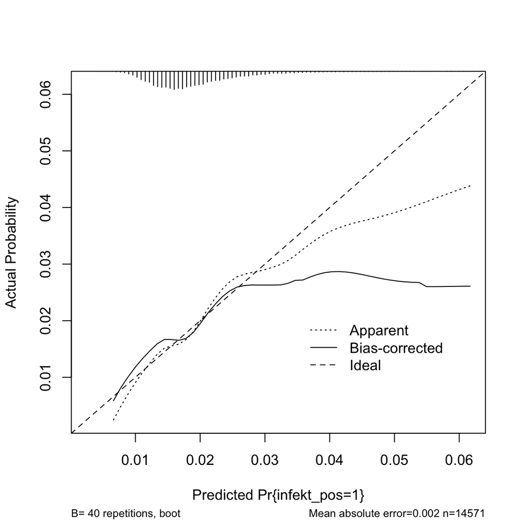

```
##
## n=14571   Mean absolute error=0.002   Mean squared error=1e-05
## 0.9 Quantile of absolute error=0.003
```

```r
library("rms")
rms.out=lrm(infekt_pos ~ female + age + hhgr + edu_school + edu_low + edu_high + edu_na +
                       inc_2000 + inc_6000 + inc_rich + inc_na + open + cons + extra + agree + neuro, data=covid_pers,x=TRUE,y=TRUE)
plot(calibrate(rms.out))
```

### Secondary analyses

Secondary analyses just with the antibodies measure (*AK_pos*) - not including PCR test results and self-reported infections.

#### Start with age and gender

##### Unweighted

```r
m1_logit_anti <- glm(AK_pos ~ female + age, family = binomial(link='logit'), data = covid_pers)
summary(m1_logit_anti)
```

```
##
## Call:
## glm(formula = AK_pos ~ female + age, family = binomial(link = "logit"),
##     data = covid_pers)
##
## Deviance Residuals:
##     Min       1Q   Median       3Q      Max
## -0.2018  -0.1771  -0.1578  -0.1427   3.0891
##
## Coefficients:
##              Estimate Std. Error z value Pr(>|z|)
## (Intercept) -3.758289   0.236048 -15.922  < 2e-16 ***
## female      -0.447953   0.147239  -3.042  0.00235 **
## age         -0.006955   0.004245  -1.638  0.10139
## ---
## Signif. codes:  0 '***' 0.001 '**' 0.01 '*' 0.05 '.' 0.1 ' ' 1
##
## (Dispersion parameter for binomial family taken to be 1)
##
##     Null deviance: 2038.7  on 14702  degrees of freedom
## Residual deviance: 2027.1  on 14700  degrees of freedom
##   (420 observations deleted due to missingness)
## AIC: 2033.1
##
## Number of Fisher Scoring iterations: 7
```

##### Weighted

```r
# apparently I need a version of the dataset without missings in the weighting variable
covid_pers_AK_only <- covid_pers %>% filter(!is.na(AK_pos))

m1_logit_anti_weighted <- svyglm(AK_pos ~ female + age, design=svydesign(id=~1, weights=~phrf_20_final_dbs, data=covid_pers_AK_only), family=quasibinomial(link='logit'))
summary(m1_logit_anti_weighted)
```

```
##
## Call:
## svyglm(formula = AK_pos ~ female + age, design = svydesign(id = ~1,
##     weights = ~phrf_20_final_dbs, data = covid_pers_AK_only),
##     family = quasibinomial(link = "logit"))
##
## Survey design:
## svydesign(id = ~1, weights = ~phrf_20_final_dbs, data = covid_pers_AK_only)
##
## Coefficients:
##              Estimate Std. Error t value Pr(>|t|)
## (Intercept) -3.558580   0.325271 -10.940   <2e-16 ***
## female      -0.158817   0.242183  -0.656   0.5120
## age         -0.014853   0.005988  -2.480   0.0131 *
## ---
## Signif. codes:  0 '***' 0.001 '**' 0.01 '*' 0.05 '.' 0.1 ' ' 1
##
## (Dispersion parameter for quasibinomial family taken to be 0.9928518)
##
## Number of Fisher Scoring iterations: 7
```

#### Add other control variables

As reference categories, I chose ‘edu_mid’ and ‘inc_4000’ because these were the most frequent categories.

##### Unweighted

```r
m2_logit_anti <- glm(AK_pos ~ female + age + hhgr + edu_school + edu_low + edu_high + edu_na +
                       inc_2000 + inc_6000 + inc_rich + inc_na, family = binomial(link='logit'), data = covid_pers)
summary(m2_logit_anti)
```

```
##
## Call:
## glm(formula = AK_pos ~ female + age + hhgr + edu_school + edu_low +
##     edu_high + edu_na + inc_2000 + inc_6000 + inc_rich + inc_na,
##     family = binomial(link = "logit"), data = covid_pers)
##
## Deviance Residuals:
##     Min       1Q   Median       3Q      Max
## -0.3452  -0.1736  -0.1555  -0.1358   3.1825
##
## Coefficients:
##              Estimate Std. Error z value Pr(>|z|)
## (Intercept) -4.365371   0.383250 -11.390  < 2e-16 ***
## female      -0.445014   0.148152  -3.004  0.00267 **
## age         -0.002014   0.004874  -0.413  0.67949
## hhgr         0.137379   0.061580   2.231  0.02569 *
## edu_school   0.144767   0.540135   0.268  0.78868
## edu_low      0.211995   0.301427   0.703  0.48186
## edu_high    -0.057220   0.176266  -0.325  0.74546
## edu_na       0.045442   0.270895   0.168  0.86678
## inc_2000    -0.096426   0.241474  -0.399  0.68965
## inc_6000    -0.379195   0.214359  -1.769  0.07690 .
## inc_rich     0.183259   0.225398   0.813  0.41619
## inc_na       0.338292   0.261849   1.292  0.19638
## ---
## Signif. codes:  0 '***' 0.001 '**' 0.01 '*' 0.05 '.' 0.1 ' ' 1
##
## (Dispersion parameter for binomial family taken to be 1)
##
##     Null deviance: 2038.7  on 14702  degrees of freedom
## Residual deviance: 2011.5  on 14691  degrees of freedom
##   (420 observations deleted due to missingness)
## AIC: 2035.5
##
## Number of Fisher Scoring iterations: 7
```

##### Weighted

```r
m2_logit_anti_weighted <- svyglm(AK_pos ~ female + age + hhgr + edu_school + edu_low + edu_high + edu_na +
                       inc_2000 + inc_6000 + inc_rich + inc_na, design=svydesign(id=~1, weights=~phrf_20_final_dbs, data=covid_pers_AK_only), family=quasibinomial(link='logit'))
summary(m2_logit_anti_weighted)
```

```
##
## Call:
## svyglm(formula = AK_pos ~ female + age + hhgr + edu_school +
##     edu_low + edu_high + edu_na + inc_2000 + inc_6000 + inc_rich +
##     inc_na, design = svydesign(id = ~1, weights = ~phrf_20_final_dbs,
##     data = covid_pers_AK_only), family = quasibinomial(link = "logit"))
##
## Survey design:
## svydesign(id = ~1, weights = ~phrf_20_final_dbs, data = covid_pers_AK_only)
##
## Coefficients:
##              Estimate Std. Error t value Pr(>|t|)
## (Intercept) -4.539043   0.616281  -7.365 1.86e-13 ***
## female      -0.152393   0.241310  -0.632   0.5277
## age         -0.005914   0.006582  -0.899   0.3689
## hhgr         0.205824   0.107514   1.914   0.0556 .
## edu_school   0.647196   0.682264   0.949   0.3428
## edu_low      0.303102   0.401682   0.755   0.4505
## edu_high    -0.049043   0.277155  -0.177   0.8595
## edu_na       0.181659   0.319714   0.568   0.5699
## inc_2000    -0.084884   0.366646  -0.232   0.8169
## inc_6000    -0.740828   0.330371  -2.242   0.0249 *
## inc_rich     0.057104   0.409424   0.139   0.8891
## inc_na       0.445217   0.297263   1.498   0.1342
## ---
## Signif. codes:  0 '***' 0.001 '**' 0.01 '*' 0.05 '.' 0.1 ' ' 1
##
## (Dispersion parameter for quasibinomial family taken to be 0.9981817)
##
## Number of Fisher Scoring iterations: 7
```

#### Add Big Five traits

##### Unweighted

```r
m3_logit_anti <- glm(AK_pos ~ female + age + hhgr + edu_school + edu_low + edu_high + edu_na +
                       inc_2000 + inc_6000 + inc_rich + inc_na + open + cons + extra + agree + neuro, family = binomial(link='logit'), data = covid_pers)
summary(m3_logit_anti)
```

```
##
## Call:
## glm(formula = AK_pos ~ female + age + hhgr + edu_school + edu_low +
##     edu_high + edu_na + inc_2000 + inc_6000 + inc_rich + inc_na +
##     open + cons + extra + agree + neuro, family = binomial(link = "logit"),
##     data = covid_pers)
##
## Deviance Residuals:
##     Min       1Q   Median       3Q      Max
## -0.3897  -0.1756  -0.1528  -0.1337   3.1815
##
## Coefficients:
##              Estimate Std. Error z value Pr(>|z|)
## (Intercept) -5.492531   0.825349  -6.655 2.84e-11 ***
## female      -0.513482   0.159192  -3.226  0.00126 **
## age         -0.001384   0.005020  -0.276  0.78282
## hhgr         0.141024   0.063175   2.232  0.02560 *
## edu_school  -0.127281   0.740934  -0.172  0.86361
## edu_low      0.134650   0.312523   0.431  0.66658
## edu_high    -0.045500   0.178460  -0.255  0.79875
## edu_na       0.092710   0.301554   0.307  0.75851
## inc_2000    -0.089917   0.243067  -0.370  0.71144
## inc_6000    -0.326785   0.215831  -1.514  0.13001
## inc_rich     0.134537   0.237098   0.567  0.57042
## inc_na       0.355698   0.272785   1.304  0.19225
## open         0.013502   0.078850   0.171  0.86404
## cons        -0.069681   0.087895  -0.793  0.42791
## extra        0.051353   0.070984   0.723  0.46940
## agree        0.175075   0.086149   2.032  0.04213 *
## neuro        0.066999   0.063452   1.056  0.29102
## ---
## Signif. codes:  0 '***' 0.001 '**' 0.01 '*' 0.05 '.' 0.1 ' ' 1
##
## (Dispersion parameter for binomial family taken to be 1)
##
##     Null deviance: 1957.3  on 14239  degrees of freedom
## Residual deviance: 1928.2  on 14223  degrees of freedom
##   (883 observations deleted due to missingness)
## AIC: 1962.2
##
## Number of Fisher Scoring iterations: 7
```

##### Weighted

```r
m3_logit_anti_weighted <- svyglm(AK_pos ~ female + age + hhgr + edu_school + edu_low + edu_high + edu_na +
                       inc_2000 + inc_6000 + inc_rich + inc_na + open + cons + extra + agree + neuro, design=svydesign(id=~1, weights=~phrf_20_final_dbs, data=covid_pers_AK_only), family=quasibinomial(link='logit'))
summary(m3_logit_anti_weighted)
```

```
##
## Call:
## svyglm(formula = AK_pos ~ female + age + hhgr + edu_school +
##     edu_low + edu_high + edu_na + inc_2000 + inc_6000 + inc_rich +
##     inc_na + open + cons + extra + agree + neuro, design = svydesign(id = ~1,
##     weights = ~phrf_20_final_dbs, data = covid_pers_AK_only),
##     family = quasibinomial(link = "logit"))
##
## Survey design:
## svydesign(id = ~1, weights = ~phrf_20_final_dbs, data = covid_pers_AK_only)
##
## Coefficients:
##              Estimate Std. Error t value Pr(>|t|)
## (Intercept) -5.564688   1.211691  -4.592 4.42e-06 ***
## female      -0.274410   0.264518  -1.037   0.2996
## age         -0.007458   0.006652  -1.121   0.2622
## hhgr         0.192674   0.108838   1.770   0.0767 .
## edu_school   0.239461   0.937179   0.256   0.7983
## edu_low      0.317434   0.384422   0.826   0.4090
## edu_high    -0.021823   0.281256  -0.078   0.9382
## edu_na       0.293681   0.337574   0.870   0.3843
## inc_2000    -0.041659   0.370675  -0.112   0.9105
## inc_6000    -0.649131   0.338599  -1.917   0.0552 .
## inc_rich     0.108906   0.427673   0.255   0.7990
## inc_na       0.554194   0.291950   1.898   0.0577 .
## open        -0.153174   0.137631  -1.113   0.2658
## cons        -0.014746   0.126512  -0.117   0.9072
## extra        0.166949   0.102741   1.625   0.1042
## agree        0.215758   0.135034   1.598   0.1101
## neuro       -0.007684   0.093469  -0.082   0.9345
## ---
## Signif. codes:  0 '***' 0.001 '**' 0.01 '*' 0.05 '.' 0.1 ' ' 1
##
## (Dispersion parameter for quasibinomial family taken to be 1.02128)
##
## Number of Fisher Scoring iterations: 7
```

#### Zero-order models

##### Unweighted

```r
open_logit_anti <- glm(AK_pos ~ open, family = binomial(link='logit'), data = covid_pers)
open_logit_anti_summary <- summary(open_logit_anti)
cons_logit_anti <- glm(AK_pos ~ cons, family = binomial(link='logit'), data = covid_pers)
cons_logit_anti_summary <- summary(cons_logit_anti)
extra_logit_anti <- glm(AK_pos ~ extra, family = binomial(link='logit'), data = covid_pers)
extra_logit_anti_summary <- summary(extra_logit_anti)
agree_logit_anti <- glm(AK_pos ~ agree, family = binomial(link='logit'), data = covid_pers)
agree_logit_anti_summary <- summary(agree_logit_anti)
neuro_logit_anti <- glm(AK_pos ~ neuro, family = binomial(link='logit'), data = covid_pers)
neuro_logit_anti_summary <- summary(neuro_logit_anti)

# Openness to Experience
round(open_logit_anti_summary$coefficients, 3)
```

```
##             Estimate Std. Error z value Pr(>|z|)
## (Intercept)   -4.431      0.366  -12.12    0.000
## open           0.018      0.072    0.25    0.803
```

```r
# Conscientiousness
round(cons_logit_anti_summary$coefficients, 3)
```

```
##             Estimate Std. Error z value Pr(>|z|)
## (Intercept)   -4.038      0.472  -8.556    0.000
## cons          -0.053      0.081  -0.650    0.516
```

```r
# Extraversion
round(extra_logit_anti_summary$coefficients, 3)
```

```
##             Estimate Std. Error z value Pr(>|z|)
## (Intercept)   -4.458      0.329 -13.563    0.000
## extra          0.024      0.065   0.364    0.716
```

```r
# Agreeableness
round(agree_logit_anti_summary$coefficients, 3)
```

```
##             Estimate Std. Error z value Pr(>|z|)
## (Intercept)   -4.966      0.451 -11.022    0.000
## agree          0.114      0.081   1.417    0.157
```

```r
# Neuroticism
round(neuro_logit_anti_summary$coefficients, 3)
```

```
##             Estimate Std. Error z value Pr(>|z|)
## (Intercept)   -4.344      0.223 -19.474    0.000
## neuro          0.001      0.059   0.009    0.993
```

##### Weighted

```r
open_logit_anti_weighted <- svyglm(AK_pos ~ open, design=svydesign(id=~1, weights=~phrf_20_final_dbs, data=covid_pers_AK_only), family=quasibinomial(link='logit'))
open_logit_anti_weighted_summary <- summary(open_logit_anti_weighted)
cons_logit_anti_weighted <- svyglm(AK_pos ~ cons, design=svydesign(id=~1, weights=~phrf_20_final_dbs, data=covid_pers_AK_only), family=quasibinomial(link='logit'))
cons_logit_anti_weighted_summary <- summary(cons_logit_anti_weighted)
extra_logit_anti_weighted <- svyglm(AK_pos ~ extra, design=svydesign(id=~1, weights=~phrf_20_final_dbs, data=covid_pers_AK_only), family=quasibinomial(link='logit'))
extra_logit_anti_weighted_summary <- summary(extra_logit_anti_weighted)
agree_logit_anti_weighted <- svyglm(AK_pos ~ agree, design=svydesign(id=~1, weights=~phrf_20_final_dbs, data=covid_pers_AK_only), family=quasibinomial(link='logit'))
agree_logit_anti_weighted_summary <- summary(agree_logit_anti_weighted)
neuro_logit_anti_weighted <- svyglm(AK_pos ~ neuro, design=svydesign(id=~1, weights=~phrf_20_final_dbs, data=covid_pers_AK_only), family=quasibinomial(link='logit'))
neuro_logit_anti_weighted_summary <- summary(neuro_logit_anti_weighted)

# Openness to Experience
round(open_logit_anti_weighted_summary$coefficients, 3)
```

```
##             Estimate Std. Error t value Pr(>|t|)
## (Intercept)   -3.955      0.660  -5.992    0.000
## open          -0.084      0.132  -0.640    0.522
```

```r
# Conscientiousness
round(cons_logit_anti_weighted_summary$coefficients, 3)
```

```
##             Estimate Std. Error t value Pr(>|t|)
## (Intercept)   -4.415      0.650  -6.791    0.000
## cons           0.009      0.112   0.084    0.933
```

```r
# Extraversion
round(extra_logit_anti_weighted_summary$coefficients, 3)
```

```
##             Estimate Std. Error t value Pr(>|t|)
## (Intercept)   -4.988      0.546  -9.134    0.000
## extra          0.127      0.107   1.188    0.235
```

```r
# Agreeableness
round(agree_logit_anti_weighted_summary$coefficients, 3)
```

```
##             Estimate Std. Error t value Pr(>|t|)
## (Intercept)   -5.383      0.660  -8.150    0.000
## agree          0.186      0.119   1.569    0.117
```

```r
# Neuroticism
round(neuro_logit_anti_weighted_summary$coefficients, 3)
```

```
##             Estimate Std. Error t value Pr(>|t|)
## (Intercept)   -4.158      0.324 -12.815    0.000
## neuro         -0.057      0.084  -0.672    0.501
```

### Model diagnostics

```r
DescTools::PseudoR2(m3_logit_anti, which="all")
```

```
##        McFadden     McFaddenAdj        CoxSnell      Nagelkerke   AldrichNelson
##    1.486157e-02   -2.509118e-03    2.040671e-03    1.589010e-02    2.038592e-03
## VeallZimmermann           Efron McKelveyZavoina            Tjur             AIC
##    1.686986e-02    2.212421e-03    4.429658e-02    2.237201e-03    1.962232e+03
##             BIC          logLik         logLik0              G2
##    2.090817e+03   -9.641159e+02   -9.786604e+02    2.908885e+01
```

Recommended Pseudo $R^2$ measures: McFadden non-adjusted and adjusted, Tjur’s D

To be added: ‘LogisticsDx’ package not available for this R version. Hosmer-Lemeshow test, Osius-Rajek Standardized Pearson Test, Stukel test.

Calibration Plot in ‘rms’ package

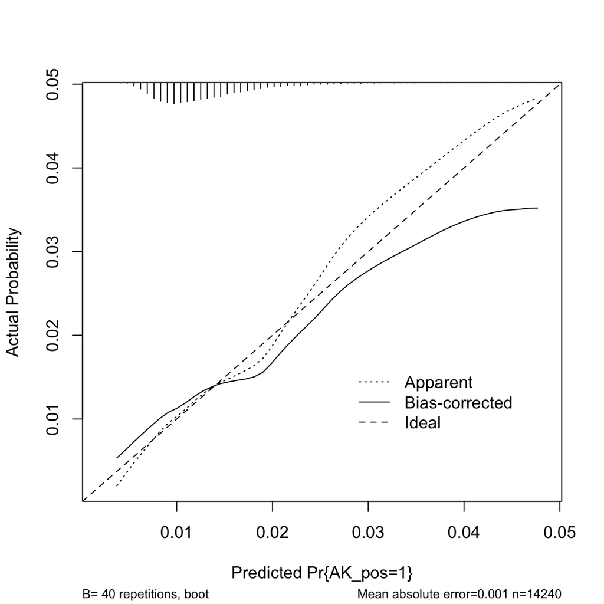

```
##
## n=14240   Mean absolute error=0.001   Mean squared error=0
## 0.9 Quantile of absolute error=0.003
```

```r
library("rms")
rms.out=lrm(AK_pos ~ female + age + hhgr + edu_school + edu_low + edu_high + edu_na +
                       inc_2000 + inc_6000 + inc_rich + inc_na + open + cons + extra + agree + neuro, data=covid_pers,x=TRUE,y=TRUE)
plot(calibrate(rms.out))
```

### Exclude Federal States

##### Unweighted

```r
# exclude via 'bula'
covid_pers_bula <- covid_pers %>% filter(bula %in% c(1:11,15:16))

m3_logit_comp_bula <- glm(infekt_pos ~ female + age + hhgr + edu_school + edu_low + edu_high + edu_na +
                       inc_2000 + inc_6000 + inc_rich + inc_na + open + cons + extra + agree + neuro, family = binomial(link='logit'), data = covid_pers_bula)
summary(m3_logit_comp_bula)
```

```
##
## Call:
## glm(formula = infekt_pos ~ female + age + hhgr + edu_school +
##     edu_low + edu_high + edu_na + inc_2000 + inc_6000 + inc_rich +
##     inc_na + open + cons + extra + agree + neuro, family = binomial(link = "logit"),
##     data = covid_pers_bula)
##
## Deviance Residuals:
##     Min       1Q   Median       3Q      Max
## -0.3800  -0.2135  -0.1902  -0.1709   3.0251
##
## Coefficients:
##              Estimate Std. Error z value Pr(>|z|)
## (Intercept) -4.900051   0.710050  -6.901 5.16e-12 ***
## female      -0.288303   0.135968  -2.120  0.03397 *
## age         -0.004257   0.004350  -0.979  0.32778
## hhgr         0.153402   0.053817   2.850  0.00437 **
## edu_school  -0.009564   0.609885  -0.016  0.98749
## edu_low     -0.119331   0.287463  -0.415  0.67806
## edu_high     0.118548   0.152575   0.777  0.43717
## edu_na       0.095928   0.261961   0.366  0.71422
## inc_2000     0.057677   0.206114   0.280  0.77961
## inc_6000    -0.382118   0.185287  -2.062  0.03918 *
## inc_rich     0.015952   0.204391   0.078  0.93779
## inc_na       0.219265   0.241974   0.906  0.36486
## open        -0.049604   0.067106  -0.739  0.45979
## cons        -0.006513   0.076117  -0.086  0.93181
## extra        0.081556   0.061329   1.330  0.18358
## agree        0.093595   0.072635   1.289  0.19755
## neuro        0.084114   0.054043   1.556  0.11961
## ---
## Signif. codes:  0 '***' 0.001 '**' 0.01 '*' 0.05 '.' 0.1 ' ' 1
##
## (Dispersion parameter for binomial family taken to be 1)
##
##     Null deviance: 2446.5  on 12780  degrees of freedom
## Residual deviance: 2418.7  on 12764  degrees of freedom
##   (499 observations deleted due to missingness)
## AIC: 2452.7
##
## Number of Fisher Scoring iterations: 7
```

```r
m3_logit_anti_bula <- glm(AK_pos ~ female + age + hhgr + edu_school + edu_low + edu_high + edu_na +
                       inc_2000 + inc_6000 + inc_rich + inc_na + open + cons + extra + agree + neuro, family = binomial(link='logit'), data = covid_pers_bula)
summary(m3_logit_anti_bula)
```

```
##
## Call:
## glm(formula = AK_pos ~ female + age + hhgr + edu_school + edu_low +
##     edu_high + edu_na + inc_2000 + inc_6000 + inc_rich + inc_na +
##     open + cons + extra + agree + neuro, family = binomial(link = "logit"),
##     data = covid_pers_bula)
##
## Deviance Residuals:
##     Min       1Q   Median       3Q      Max
## -0.3946  -0.1805  -0.1572  -0.1366   3.1646
##
## Coefficients:
##              Estimate Std. Error z value Pr(>|z|)
## (Intercept) -5.178978   0.852349  -6.076 1.23e-09 ***
## female      -0.539170   0.165944  -3.249  0.00116 **
## age         -0.001879   0.005213  -0.360  0.71853
## hhgr         0.134263   0.065011   2.065  0.03890 *
## edu_school  -0.050413   0.743606  -0.068  0.94595
## edu_low      0.155976   0.314741   0.496  0.62020
## edu_high    -0.028828   0.187351  -0.154  0.87771
## edu_na       0.053440   0.312473   0.171  0.86421
## inc_2000    -0.090911   0.258409  -0.352  0.72498
## inc_6000    -0.334978   0.224042  -1.495  0.13487
## inc_rich     0.111507   0.244823   0.455  0.64878
## inc_na       0.366543   0.281932   1.300  0.19356
## open        -0.013689   0.081366  -0.168  0.86640
## cons        -0.055145   0.090826  -0.607  0.54375
## extra        0.032208   0.073429   0.439  0.66094
## agree        0.157255   0.088967   1.768  0.07713 .
## neuro        0.075350   0.065729   1.146  0.25164
## ---
## Signif. codes:  0 '***' 0.001 '**' 0.01 '*' 0.05 '.' 0.1 ' ' 1
##
## (Dispersion parameter for binomial family taken to be 1)
##
##     Null deviance: 1790.3  on 12500  degrees of freedom
## Residual deviance: 1763.5  on 12484  degrees of freedom
##   (779 observations deleted due to missingness)
## AIC: 1797.5
##
## Number of Fisher Scoring iterations: 7
```

##### Weighted

```r
# exclude via 'bula'
covid_pers_AK_only_bula <- covid_pers_AK_only %>% filter(bula %in% c(1:11,15:16))

m3_logit_comp_bula_weighted <- svyglm(infekt_pos ~ female + age + hhgr + edu_school + edu_low + edu_high +
                                        edu_na + inc_2000 + inc_6000 + inc_rich + inc_na + open + cons +
                                        extra + agree + neuro, design=svydesign(id=~1, weights=~phrf_20_final, data=covid_pers_bula), family=quasibinomial(link='logit'))
summary(m3_logit_comp_bula_weighted)
```

```
##
## Call:
## svyglm(formula = infekt_pos ~ female + age + hhgr + edu_school +
##     edu_low + edu_high + edu_na + inc_2000 + inc_6000 + inc_rich +
##     inc_na + open + cons + extra + agree + neuro, design = svydesign(id = ~1,
##     weights = ~phrf_20_final, data = covid_pers_bula), family = quasibinomial(link = "logit"))
##
## Survey design:
## svydesign(id = ~1, weights = ~phrf_20_final, data = covid_pers_bula)
##
## Coefficients:
##              Estimate Std. Error t value Pr(>|t|)
## (Intercept) -5.354442   1.122215  -4.771 1.85e-06 ***
## female       0.098236   0.217947   0.451   0.6522
## age         -0.009378   0.006530  -1.436   0.1510
## hhgr         0.181637   0.089042   2.040   0.0414 *
## edu_school   0.652372   0.748250   0.872   0.3833
## edu_low     -0.109091   0.356932  -0.306   0.7599
## edu_high     0.042219   0.271606   0.155   0.8765
## edu_na       0.178860   0.413422   0.433   0.6653
## inc_2000    -0.006566   0.290992  -0.023   0.9820
## inc_6000    -0.730149   0.324563  -2.250   0.0245 *
## inc_rich    -0.383548   0.382061  -1.004   0.3154
## inc_na       0.437482   0.369572   1.184   0.2365
## open        -0.158551   0.124314  -1.275   0.2022
## cons         0.022757   0.119059   0.191   0.8484
## extra        0.252142   0.102098   2.470   0.0135 *
## agree        0.145673   0.114412   1.273   0.2030
## neuro        0.015006   0.072503   0.207   0.8360
## ---
## Signif. codes:  0 '***' 0.001 '**' 0.01 '*' 0.05 '.' 0.1 ' ' 1
##
## (Dispersion parameter for quasibinomial family taken to be 1.005361)
##
## Number of Fisher Scoring iterations: 7
```

```r
m3_logit_anti_bula_weighted <- svyglm(AK_pos ~ female + age + hhgr + edu_school + edu_low + edu_high +
                                        edu_na + inc_2000 + inc_6000 + inc_rich + inc_na + open + cons +
                                        extra + agree + neuro, design=svydesign(id=~1, weights=~phrf_20_final_dbs, data=covid_pers_AK_only_bula), family=quasibinomial(link='logit'))
summary(m3_logit_anti_bula_weighted)
```

```
##
## Call:
## svyglm(formula = AK_pos ~ female + age + hhgr + edu_school +
##     edu_low + edu_high + edu_na + inc_2000 + inc_6000 + inc_rich +
##     inc_na + open + cons + extra + agree + neuro, design = svydesign(id = ~1,
##     weights = ~phrf_20_final_dbs, data = covid_pers_AK_only_bula),
##     family = quasibinomial(link = "logit"))
##
## Survey design:
## svydesign(id = ~1, weights = ~phrf_20_final_dbs, data = covid_pers_AK_only_bula)
##
## Coefficients:
##              Estimate Std. Error t value Pr(>|t|)
## (Intercept) -5.482215   1.240214  -4.420 9.94e-06 ***
## female      -0.253031   0.275392  -0.919   0.3582
## age         -0.006285   0.006478  -0.970   0.3319
## hhgr         0.211290   0.110508   1.912   0.0559 .
## edu_school   0.331788   0.943630   0.352   0.7251
## edu_low      0.311328   0.389048   0.800   0.4236
## edu_high    -0.002673   0.296775  -0.009   0.9928
## edu_na       0.264715   0.349235   0.758   0.4485
## inc_2000     0.041978   0.389752   0.108   0.9142
## inc_6000    -0.669458   0.354089  -1.891   0.0587 .
## inc_rich     0.107680   0.430479   0.250   0.8025
## inc_na       0.590073   0.301015   1.960   0.0500 *
## open        -0.144229   0.141848  -1.017   0.3093
## cons        -0.044728   0.125146  -0.357   0.7208
## extra        0.139795   0.104316   1.340   0.1802
## agree        0.221992   0.140762   1.577   0.1148
## neuro        0.005516   0.097190   0.057   0.9547
## ---
## Signif. codes:  0 '***' 0.001 '**' 0.01 '*' 0.05 '.' 0.1 ' ' 1
##
## (Dispersion parameter for quasibinomial family taken to be 1.019274)
##
## Number of Fisher Scoring iterations: 7
```

### To Be Done (?)

- Imputations?
- “For the same reason, in another additional analysis, we plan to exclude participants who indicated to have mostly worked from home during the coronavirus crisis.”
- “Lastly, due to the rising incidence rates in Germany during the field phase we will analyze timing of the administration of the antibody tests (measured by postal return date) as a moderator by comparing effects in the first third of all conducted test against effects in the last third of all conducted tests.”